# Hands On 2: Web Usage Mining

### For R beginners

New chunk *Ctrl+Alt+I*

Execute chunk *Ctrl+Shift+Enter*

Execute all chunks *Ctrl+Alt+R*

HTML preview *Ctrl+Shift+K*

# 2.1 Simple Recommendation Strategies

```r
# Preparations
library(dplyr)
df <- read.csv("~/4year/2semester/dtII/CSVs/log.csv")
View(df)
```

## Most Visited Pages

1. Recommend the 3 most visited pages. For that purpose:

```r
# a) inspect how many times each page was visited.
df %>% group_by(PAGE) %>% count()
```

| PAGE | n |
| --- | --- |
| A | 3 |
| B | 3 |
| C | 4 |
| F | 2 |
| G | 2 |
| I | 2 |
| J | 1 |

```r
# b) sort the pages by decreasing number of visits.
df %>% group_by(PAGE) %>% count() %>% arrange(desc(n))
```

| PAGE | n |
| --- | --- |
| C | 4 |
| A | 3 |
| B | 3 |
| F | 2 |
| G | 2 |
| I | 2 |
| J | 1 |

```r
# different method with tally function that does the same as count and arrange combined
# df %>% group_by(PAGE) %>% tally(sort = TRUE)
```

```r
# c) obtain the top 3 pages for recommendation.
# pull() extracts a single column from the data frame and makes it a vector
df %>% group_by(PAGE) %>% tally(sort = TRUE) %>% top_n(3) %>% pull(PAGE)
```

```
[1] "C" "A" "B"
```

## Using Clustering Results

2. Suppose we want to form two clusters of users, according to the pages they have visited. For that purpose:

```r
# a) start by transforming the log access data into a matrix that has on each row a user and for each user the information on his visits to each page; this can be obtained with the table() function.
dat <- table(df$USER, df$PAGE)
dat
```

```
     A B C F G I J
  u1 1 1 1 0 0 0 0
  u2 1 0 1 0 0 0 0
  u3 0 1 0 1 1 1 0
  u4 0 1 1 0 0 0 0
  u5 0 0 0 1 1 1 1
  u6 1 0 1 0 0 0 0
```

```r
# b) use the function dist() to obtain a distance matrix with the Euclidean distance between the users.
dm <- dist(dat)
dm
```

```
         u1       u2       u3       u4       u5
u2 1.000000
u3 2.236068 2.449490
u4 1.000000 1.414214 2.000000
u5 2.645751 2.449490 1.414214 2.449490
u6 1.000000 0.000000 2.449490 1.414214 2.449490
```

```r
# c) check for alternatives in the help page of dist().
# others "maximun", "manhattan", "minkowski", "jaccard"
```

```r
# Package shown by professor in class
library(recommenderlab)
summary(pr_DB)
```

```
* Similarity measures:
angular, Braun-Blanquet, Chi-squared, correlation, cosine, Cramer, Dice, eDice, eJaccard, Fager, Faith, Gower, Hamman, Jaccard,
Kulczynski1, Kulczynski2, Michael, Mountford, Mozley, Ochiai, Pearson, Phi, Phi-squared, Russel, simple matching, Simpson, Stiles,
Tanimoto, Tschuprow, Yule, Yule2

* Distance measures:
Bhjattacharyya, Bray, Canberra, Chord, divergence, Euclidean, fJaccard, Geodesic, Hellinger, Kullback, Levenshtein, Mahalanobis,
Manhattan, Minkowski, Podani, Soergel, supremum, Wave, Whittaker
```

```r
dm <- dist(dat, method = "jaccard")
```

```r
# d) use the function hclust() with the distance matrix to obtain an agglomerative clustering model of this data.
c1 <- hclust(dm)
```

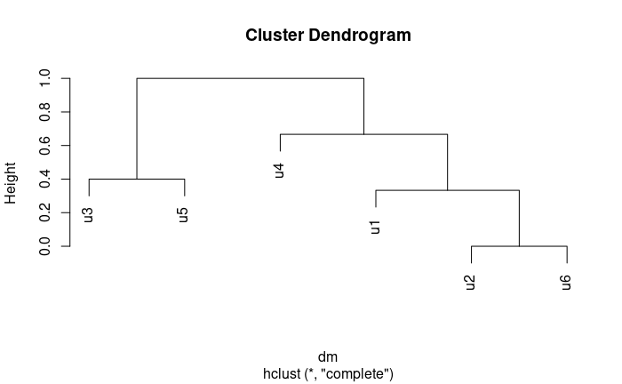

```r
# e) visualize the obtained dendogram with function plot().
plot(c1)
```

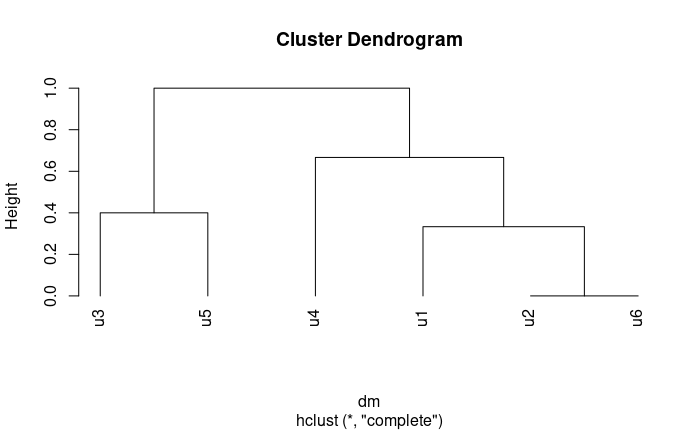

```r
# f) visualize the dendogram again, but now with option hang=-0.1.
plot(c1, hang=-0.1)
```

```r
# g) use the function cutree() to ”cut” the hierarchical clustering in just two clusters; inspect the cluster membership of each user.
cm <- cutree(c1,2)
cm
```

```
u1 u2 u3 u4 u5 u6
 1  1  2  1  2  1
```

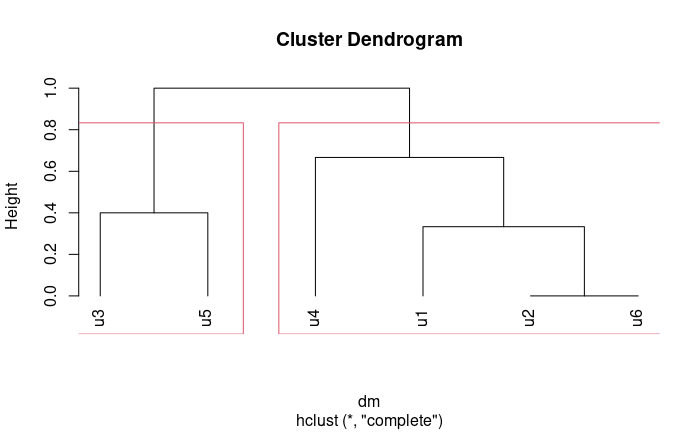

```r
# h) use the function rect.hclust() to draw the previous solution in the dendogram.
plot(c1, hang=-0.1)
rect.hclust(c1,2)
```

3. Recommend the top 2 pages for users of cluster 1. For that purpose:

```r
# a) inspect what were the pages visited by users in cluster 1.

# with mutate we can add the cluster to each user belongs to the df table
dd <- mutate(df, Cluster=cm[df$USER])
dd
```

| USER | PAGE | Cluster |
| --- | --- | --- |
| u1 | A | 1 |
| u1 | B | 1 |
| u1 | C | 1 |
| u2 | A | 1 |
| u2 | C | 1 |
| u3 | B | 2 |
| u3 | G | 2 |
| u3 | F | 2 |
| u3 | I | 2 |
| u4 | B | 1 |

[output cut: 7 more lines]

```r
filter(dd,Cluster==1) %>% select(PAGE)
```

| PAGE |
| --- |
| A |
| B |
| C |
| A |
| C |
| B |
| C |
| A |
| C |

```r
# b) inspect how many times each of these pages was visited.
filter(dd,Cluster==1) %>% select(PAGE) %>% group_by(PAGE) %>% count()
```

| PAGE | n |
| --- | --- |
| A | 3 |
| B | 2 |
| C | 4 |

```r
# c) sort the pages by decreasing order of visits.
filter(dd,Cluster==1) %>% select(PAGE) %>% group_by(PAGE) %>% tally(sort=TRUE)
```

| PAGE | n |
| --- | --- |
| C | 4 |
| A | 3 |
| B | 2 |

```r
# d) obtain the top 2 pages for recommendation.
filter(dd,Cluster==1) %>% select(PAGE) %>% group_by(PAGE) %>% tally(sort=TRUE) %>% top_n(2) %>% pull(PAGE)
```

```
[1] "C" "A"
```

4. Recommend the top 2 pages for users of cluster 2.

```r
filter(dd,Cluster==2) %>% select(PAGE) %>% group_by(PAGE) %>% tally(sort=TRUE) %>% top_n(2) %>% pull(PAGE)
```

```
[1] "F" "G" "I"
```

5. Using the same clustering results, recommend the top 3 pages for user u2. From those top pages you should remove the pages that the user has already visited.

```r
# First, get the cluster of user2
cluster.u2 <-
dd %>% filter(USER=="u2") %>% select(Cluster) %>% head(1) %>% pull()
cluster.u2
```

```
u2
 1
```

```r
# Second, get top3 pages from cluster for user2
rec.u2 <-
  filter(dd,Cluster==cluster.u2) %>% group_by(PAGE) %>% tally(sort=TRUE) %>% top_n(3) %>% select(PAGE)
rec.u2
```

| PAGE |
| --- |
| C |
| A |
| B |

```r
# Third, get pages already visited by user2
seen.u2 <-
  dd %>% filter(USER=="u2") %>% select(PAGE)
seen.u2
```

| PAGE |
| --- |
| A |
| C |

```r
# Finally, show what isn't in both groups
anti_join(rec.u2, seen.u2)
```

| PAGE |
| --- |
| B |

# 2.2 Recommendation using Association Rules

Load the package recommenderlab and read the log1.csv file (it is an expansion of log.csv with u7 and u8).

```r
# Preparations
library(recommenderlab)
library(readr)
log <- read_csv("~/4year/2semester/dtII/CSVs/log1.csv", col_types=list(col_factor(), col_factor()))
View(log)
```

6. Obtain a recommendation model using association rules with the first 6 users.

```r
# a) start by coercing the data frame with user-page access information from the log1.csv file to a binaryRatingMatrix (brm).
brm <- as(as.data.frame(log), "binaryRatingMatrix")
brm
```

```
8 x 7 rating matrix of class ‘binaryRatingMatrix’ with 20 ratings.
```

```r
# in order to check out what we have in the data frame
getData.frame(brm)
```

|  | user | item | rating |
| --- | --- | --- | --- |
| 1 | u1 | A | 1 |
| 4 | u1 | B | 1 |
| 7 | u1 | C | 1 |
| 2 | u2 | A | 1 |
| 8 | u2 | C | 1 |
| 5 | u3 | B | 1 |
| 13 | u3 | G | 1 |
| 15 | u3 | F | 1 |
| 18 | u3 | I | 1 |
| 6 | u4 | B | 1 |

[output cut: 10 more lines]

```r
# b) select the information on the first 6 users to be used as training offline data and save it to a new variable (e.g brm_offline).
brm_offline <- brm[1:6,]
```

```r
# c) inspect the content of brm_offline; use the function getRatingMatrix and getData.frame.
getData.frame(brm_offline)
```

|  | user | item | rating |
| --- | --- | --- | --- |
| 1 | u1 | A | 1 |
| 4 | u1 | B | 1 |
| 7 | u1 | C | 1 |
| 2 | u2 | A | 1 |
| 8 | u2 | C | 1 |
| 5 | u3 | B | 1 |
| 11 | u3 | G | 1 |
| 13 | u3 | F | 1 |
| 15 | u3 | I | 1 |
| 6 | u4 | B | 1 |

[output cut: 7 more lines]

```r
getRatingMatrix(brm_offline)
```

```
itemMatrix in sparse format with
 6 rows (elements/transactions) and
 7 columns (items)
```

```r
# the best way lo 'look' at rating matrices
inspect(getRatingMatrix(brm_offline))
```

|  | items |
| --- | --- |
| [1] | {A, B, C} |
| [2] | {A, C} |
| [3] | {B, G, F, I} |
| [4] | {B, C} |
| [5] | {G, F, I, J} |
| [6] | {A, C} |

```r
# d) apply the functions rowCounts and colCounts to brm_offline; what information does it give you?
r <- rowCounts(brm_offline)
r
```

```
u1 u2 u3 u4 u5 u6
 3  2  4  2  4  2
```

```r
c <- colCounts(brm_offline)
c
```

```
A B C G F I J
3 3 4 2 2 2 1
```

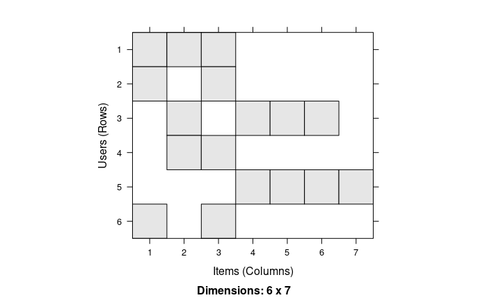

```r
# e) apply the function image to brm_offline.
image(brm_offline)
```

```r
# f) obtain the recommender model based on association rules with the instruction: modelAR <- Recommender(brm_offline,"AR").
modelAR <- Recommender(brm_offline, "AR") # AR -> Association Rules
modelAR
```

```
Recommender of type ‘AR’ for ‘binaryRatingMatrix’
learned using 6 users.
```

```r
# g) apply the function getModel to the obtained model and then inspect the association rules that compose the model.
getModel(modelAR)
```

```
$description
[1] "AR: rule base"

$rule_base
set of 26 rules

$support
[1] 0.1

$confidence
[1] 0.8

$maxlen
[1] 3

$maxtime
[1] 5

$sort_measure
[1] "confidence"

$sort_decreasing
[1] TRUE

$apriori_control
$apriori_control$verbose
[1] FALSE


$verbose
[1] FALSE
```

```r
# generation of rules
rules <- getModel(modelAR)$rule_base
inspect(rules)
```

|  | lhs |  | rhs | support | confidence | coverage | lift | count |
| --- | --- | --- | --- | --- | --- | --- | --- | --- |
| [1] | {J} | => | {G} | 0.1666667 | 1 | 0.1666667 | 3.0 | 1 |
| [2] | {J} | => | {F} | 0.1666667 | 1 | 0.1666667 | 3.0 | 1 |
| [3] | {J} | => | {I} | 0.1666667 | 1 | 0.1666667 | 3.0 | 1 |
| [4] | {A} | => | {C} | 0.5000000 | 1 | 0.5000000 | 1.5 | 3 |
| [5] | {G} | => | {F} | 0.3333333 | 1 | 0.3333333 | 3.0 | 2 |
| [6] | {F} | => | {G} | 0.3333333 | 1 | 0.3333333 | 3.0 | 2 |
| [7] | {G} | => | {I} | 0.3333333 | 1 | 0.3333333 | 3.0 | 2 |
| [8] | {I} | => | {G} | 0.3333333 | 1 | 0.3333333 | 3.0 | 2 |
| [9] | {F} | => | {I} | 0.3333333 | 1 | 0.3333333 | 3.0 | 2 |
| [10] | {I} | => | {F} | 0.3333333 | 1 | 0.3333333 | 3.0 | 2 |

[output cut: 16 more lines]

7. Suppose that u7 enters the system and becomes an active user. Deploy the recommendation model for him/her.

```r
# Getting old values of user 7
brm_u7 <- brm[7,]
# Checking the contents
getData.frame(brm_u7)
```

|  | user | item | rating |
| --- | --- | --- | --- |
| 1 | u7 | C | 1 |
| 2 | u7 | F | 1 |

```r
# a) apply the predict function with the model and the rating matrix of the user, such that only the top 2 recommendations are given as output.
recsAR <- predict(modelAR, brm_u7, n=2)
recsAR
```

```
Recommendations as ‘topNList’ with n = 2 for 1 users.
```

```r
# b) apply the function getList to the obtained predictions to inspect the actual recommendations; which are they?
getList(recsAR)
```

```
$`0`
[1] "G" "I"
```

```r
# c) to comprove the obtained recommendations, filter the rules which have been triggered for this active user.
r <- subset(rules, lhs %in% c("C", "F"))
inspect(r)
```

|  | lhs |  | rhs | support | confidence | coverage | lift | count |
| --- | --- | --- | --- | --- | --- | --- | --- | --- |
| [1] | {F} | => | {G} | 0.3333333 | 1 | 0.3333333 | 3 | 2 |
| [2] | {F} | => | {I} | 0.3333333 | 1 | 0.3333333 | 3 | 2 |
| [3] | {F, J} | => | {G} | 0.1666667 | 1 | 0.1666667 | 3 | 1 |
| [4] | {F, J} | => | {I} | 0.1666667 | 1 | 0.1666667 | 3 | 1 |
| [5] | {G, F} | => | {I} | 0.3333333 | 1 | 0.3333333 | 3 | 2 |
| [6] | {F, I} | => | {G} | 0.3333333 | 1 | 0.3333333 | 3 | 2 |
| [7] | {B, F} | => | {G} | 0.1666667 | 1 | 0.1666667 | 3 | 1 |
| [8] | {B, F} | => | {I} | 0.1666667 | 1 | 0.1666667 | 3 | 1 |

8. Now suppose that u8 enters the system and becomes an active user. Deploy the recommendation model for him/her. Be critical regarding the results.

```r
brm_u8 <- brm[8,]
getData.frame(brm_u8)
```

|  | user | item | rating |
| --- | --- | --- | --- |
| 1 | u8 | C | 1 |

```r
recs8AR <- predict(modelAR, brm_u8, n=2)
recs8AR
```

```
Recommendations as ‘topNList’ with n = 2 for 1 users.
```

```r
getList(recs8AR)
```

```
$`0`
character(0)
```

9. Explore the types of recommendation models available for binary rating matrices.

```r
recommenderRegistry$get_entries(dataType="binaryRatingMatrix")
```

```
$HYBRID_binaryRatingMatrix
Recommender method: HYBRID for binaryRatingMatrix Description: Hybrid recommender that aggegates several recommendation strategies
  using weighted averages. Reference: NA
Parameters:
```

| recommenders | weights | aggregation_type |
| --- | --- | --- |
| NULL | NULL | "sum" |

```
$ALS_implicit_binaryRatingMatrix
Recommender method: ALS_implicit for binaryRatingMatrix Description: Recommender for implicit data based on latent factors, calculated
  by alternating least squares algorithm. Reference: Yifan Hu, Yehuda Koren, Chris Volinsky (2008). Collaborative Filtering for
  Implicit Feedback Datasets, ICDM '08 Proceedings of the 2008 Eighth IEEE International Conference on Data Mining, pages 263-272.
Parameters:
```

| lambda | alpha | n_factors | n_iterations | min_item_nr | seed |
| --- | --- | --- | --- | --- | --- |
| 0.1 | 10 | 10 | 10 | 1 | NULL |

```
$AR_binaryRatingMatrix
Recommender method: AR for binaryRatingMatrix Description: Recommender based on association rules. Reference: NA
Parameters:
```

| support | confidence | maxlen | maxtime | sort_measure | sort_decreasing | apriori_control | verbose |
| --- | --- | --- | --- | --- | --- | --- | --- |
| 0.1 | 0.8 | 3 | 5 | "confidence" | TRUE | list() | FALSE |

```
$IBCF_binaryRatingMatrix
Recommender method: IBCF for binaryRatingMatrix Description: Recommender based on item-based collaborative filtering (binary rating
  data). Reference: NA
Parameters:
```

| k | method | normalize_sim_matrix | alpha |
| --- | --- | --- | --- |
| 30 | "Jaccard" | FALSE | 0.5 |

```
$POPULAR_binaryRatingMatrix
Recommender method: POPULAR for binaryRatingMatrix Description: Recommender based on item popularity. Reference: NA
Parameters: None

$RANDOM_binaryRatingMatrix
Recommender method: RANDOM for binaryRatingMatrix Description: Produce random recommendations (binary ratings). Reference: NA
Parameters: None

$RERECOMMEND_binaryRatingMatrix
Recommender method: RERECOMMEND for binaryRatingMatrix Description: Re-recommends items (binary ratings). Reference: NA
Parameters:
```

```
$UBCF_binaryRatingMatrix
Recommender method: UBCF for binaryRatingMatrix Description: Recommender based on user-based collaborative filtering. Reference: NA
Parameters:
```

| method | nn | weighted | sample | min_matching_items | min_predictive_items |
| --- | --- | --- | --- | --- | --- |
| "jaccard" | 25 | TRUE | FALSE | 0 | 0 |

```
NA
```

10. Make the top 2 recommendations to u7 and u8 using the popularity of the pages, instead of association rules. Try to understand the obtained recommendations.

```r
modelPop <- Recommender(brm_offline, "POPULAR")

recsPop <- predict(modelPop, brm[7:8,], n=2)
recsPop
```

```
Recommendations as ‘topNList’ with n = 2 for 2 users.
```

```r
getList(recsPop)
```

```
$`0`
[1] "A" "B"

$`1`
[1] "A" "B"
```

# 2.3 Recommendation using Collaborative Filtering

## Binary Rating Data

Considering the same binary rating matrix of the previous exercise brm_offline, build a recommendation model based on collaborative filtering.

11. Start by using the function similarity to build the similarity cosine matrix (only for first 6 users).

```r
# a) a user-based approach.
sCos_users <- similarity(brm_offline, method="cosine")
sCos_users
```

```
          u1        u2        u3        u4        u5
u2 0.9082483
u3 0.6443376 0.5000000
u4 0.9082483 0.7500000 0.6767767
u5 0.5000000 0.5000000 0.8750000 0.5000000
u6 0.9082483 1.0000000 0.5000000 0.7500000 0.5000000
```

```r
# b) an item-based approach.
sCos_items <- similarity(brm_offline, method ="cosine", which="items")
sCos_items
```

```
          A         B         C         G         F         I
B 0.6666667
C 0.9330127 0.7886751
G 0.5000000 0.7041241 0.5000000
F 0.5000000 0.7041241 0.5000000 1.0000000
I 0.5000000 0.7041241 0.5000000 1.0000000 1.0000000
J 0.5000000 0.5000000 0.5000000 0.8535534 0.8535534 0.8535534
```

12. Obtain the top 2 recommendations with user-based CF and item-based CF methods using the cosine similarity with a neighborhood of size 3, for:

```r
# model creation for user-based and item-based collaborative filtering
modelUBCF <- Recommender(brm_offline, 'UBCF', parameter=list(method="cosine" ,nn=3))
getModel(modelUBCF)
```

```
$description
[1] "UBCF-Binary Data: contains full or sample of data set"

$data
6 x 7 rating matrix of class ‘binaryRatingMatrix’ with 17 ratings.

$method
[1] "cosine"

$nn
[1] 3

$weighted
[1] TRUE

$sample
[1] FALSE

$min_matching_items
[1] 0

$min_predictive_items
[1] 0

$verbose
[1] FALSE
```

```r
modelIBCF <- Recommender(brm_offline, 'IBCF', parameter=list(method="cosine" ,k=3))
getModel(modelIBCF)
```

```
$description
[1] "IBCF: Reduced similarity matrix"

$sim
          A         B         C         G         F         I         J
A 0.0000000 0.6666667 0.9330127 0.0000000 0.0000000 0.0000000 0.5000000
B 0.0000000 0.0000000 0.7886751 0.0000000 0.7041241 0.7041241 0.0000000
C 0.9330127 0.7886751 0.0000000 0.0000000 0.0000000 0.0000000 0.5000000
G 0.0000000 0.0000000 0.0000000 0.0000000 1.0000000 1.0000000 0.8535534
F 0.0000000 0.0000000 0.0000000 1.0000000 0.0000000 1.0000000 0.8535534
I 0.0000000 0.0000000 0.0000000 1.0000000 1.0000000 0.0000000 0.8535534
J 0.0000000 0.0000000 0.0000000 0.8535534 0.8535534 0.8535534 0.0000000

$k
[1] 3

$method
[1] "cosine"

$normalize_sim_matrix
[1] FALSE

$alpha
[1] 0.5

$verbose
[1] FALSE
```

```r
# a) active user u8
recsUBCF <- predict(modelUBCF, brm_u8, n=2)
getList(recsUBCF)
```

```
$`0`
[1] "A" "B"
```

```r
recsIBCF <- predict(modelIBCF, brm_u8, n=2)
getList(recsIBCF)
```

```
$`0`
[1] "A" "B"
```

```r
# b) active user u7
recsUBCF <- predict(modelUBCF, brm_u7, n=2)
getList(recsUBCF)
```

```
$`0`
[1] "A" "B"
```

```r
recsIBCF <- predict(modelIBCF, brm_u7, n=2)
getList(recsIBCF)
```

```
$`0`
[1] "G" "I"
```

## Non-Binary Rating Data

13. Explore the types of recommendation models available for real rating matrices

```r
recommenderRegistry$get_entries(dataType ="realRatingMatrix")
```

```
$HYBRID_realRatingMatrix
Recommender method: HYBRID for realRatingMatrix Description: Hybrid recommender that aggegates several recommendation strategies using
  weighted averages. Reference: NA
Parameters:
```

| recommenders | weights | aggregation_type |
| --- | --- | --- |
| NULL | NULL | "sum" |

```
$ALS_realRatingMatrix
Recommender method: ALS for realRatingMatrix Description: Recommender for explicit ratings based on latent factors, calculated by
  alternating least squares algorithm. Reference: Yunhong Zhou, Dennis Wilkinson, Robert Schreiber, Rong Pan (2008). Large-Scale
  Parallel Collaborative Filtering for the Netflix Prize, 4th Int'l Conf. Algorithmic Aspects in Information and Management, LNCS
  5034.
Parameters:
```

| normalize | lambda | n_factors | n_iterations | min_item_nr | seed |
| --- | --- | --- | --- | --- | --- |
| NULL | 0.1 | 10 | 10 | 1 | NULL |

```
$ALS_implicit_realRatingMatrix
Recommender method: ALS_implicit for realRatingMatrix Description: Recommender for implicit data based on latent factors, calculated
  by alternating least squares algorithm. Reference: Yifan Hu, Yehuda Koren, Chris Volinsky (2008). Collaborative Filtering for
  Implicit Feedback Datasets, ICDM '08 Proceedings of the 2008 Eighth IEEE International Conference on Data Mining, pages 263-272.
Parameters:
```

| lambda | alpha | n_factors | n_iterations | min_item_nr | seed |
| --- | --- | --- | --- | --- | --- |
| 0.1 | 10 | 10 | 10 | 1 | NULL |

```
$IBCF_realRatingMatrix
Recommender method: IBCF for realRatingMatrix Description: Recommender based on item-based collaborative filtering. Reference: NA
Parameters:
```

| k | method | normalize | normalize_sim_matrix | alpha | na_as_zero |
| --- | --- | --- | --- | --- | --- |
| 30 | "cosine" | "center" | FALSE | 0.5 | FALSE |

```
$LIBMF_realRatingMatrix
Recommender method: LIBMF for realRatingMatrix Description: Matrix factorization with LIBMF via package recosystem
  (https://cran.r-project.org/web/packages/recosystem/vignettes/introduction.html). Reference: NA
Parameters:
```

| dim | costp_l2 | costq_l2 | nthread | verbose |
| --- | --- | --- | --- | --- |
| 10 | 0.01 | 0.01 | 1 | FALSE |

```
$POPULAR_realRatingMatrix
Recommender method: POPULAR for realRatingMatrix Description: Recommender based on item popularity. Reference: NA
Parameters:
```

| normalize | aggregationRatings | aggregationPopularity |
| --- | --- | --- |
| "center" | new("standardGeneric", .Data = function (x, na.rm = FALSE, dims = 1, | new("standardGeneric", .Data = function (x, na.rm = FALSE, dims = 1, |

```
$RANDOM_realRatingMatrix
Recommender method: RANDOM for realRatingMatrix Description: Produce random recommendations (real ratings). Reference: NA
Parameters: None

$RERECOMMEND_realRatingMatrix
Recommender method: RERECOMMEND for realRatingMatrix Description: Re-recommends highly rated items (real ratings). Reference: NA
Parameters:
```

| randomize | minRating |
| --- | --- |
| 1 | NA |

```
$SVD_realRatingMatrix
Recommender method: SVD for realRatingMatrix Description: Recommender based on SVD approximation with column-mean imputation.
  Reference: NA
Parameters:
```

| k | maxiter | normalize |
| --- | --- | --- |
| 10 | 100 | "center" |

```
$SVDF_realRatingMatrix
Recommender method: SVDF for realRatingMatrix Description: Recommender based on Funk SVD with gradient descend
  (https://sifter.org/~simon/journal/20061211.html). Reference: NA
Parameters:
```

| k | gamma | lambda | min_epochs | max_epochs | min_improvement | normalize | verbose |
| --- | --- | --- | --- | --- | --- | --- | --- |
| 10 | 0.015 | 0.001 | 50 | 200 | 1e-06 | "center" | FALSE |

```
$UBCF_realRatingMatrix
Recommender method: UBCF for realRatingMatrix Description: Recommender based on user-based collaborative filtering. Reference: NA
Parameters:
```

| method | nn | sample | weighted | normalize | min_matching_items | min_predictive_items |
| --- | --- | --- | --- | --- | --- | --- |
| "cosine" | 25 | FALSE | TRUE | "center" | 0 | 0 |

```
NA
```

14. Read the file log1Ratings.csv, containing information on the ratings given to web pages by a set of users, into a data frame in R. Build and deploy the following collaborative filtering recommendation models using, again, the first 6 users for training:

```r
logR <- read_csv("~/4year/2semester/dtII/CSVs/log1Ratings.csv",
                      col_types=list(col_factor(),
                                     col_factor(),
                                     col_integer()))

rrm <- as(as.data.frame(logR), "realRatingMatrix")

getRatingMatrix(rrm)
```

```
8 x 7 sparse Matrix of class "dgCMatrix"
   A B C G F I J
u1 1 3 2 . . . .
u2 4 . 2 . . . .
u3 . 4 . 5 3 4 .
u4 . 5 4 . . . .
u5 . . . 3 4 5 3
u6 5 . 3 . . . .
u7 . . 4 . 1 . .
u8 . . 2 . . . .
```

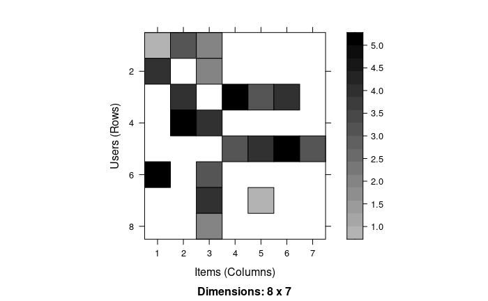

```r
image(rrm)
```

```r
# using only first 6 users
rrm_offline <- rrm[1:6,]
getRatingMatrix(rrm_offline)
```

```
6 x 7 sparse Matrix of class "dgCMatrix"
   A B C G F I J
u1 1 3 2 . . . .
u2 4 . 2 . . . .
u3 . 4 . 5 3 4 .
u4 . 5 4 . . . .
u5 . . . 3 4 5 3
u6 5 . 3 . . . .
```

```r
# a) a user-based CF approach with two neighbors to predict the ratings of users u7 and u8

# model creation
modelUBCF_R <- Recommender(rrm_offline, 'UBCF', parameter=list(nn=2))
getModel(modelUBCF_R)
```

```
$description
[1] "UBCF-Real data: contains full or sample of data set"

$data
6 x 7 rating matrix of class ‘realRatingMatrix’ with 17 ratings.
Normalized using center on rows.

$method
[1] "cosine"

$nn
[1] 2

$sample
[1] FALSE

$weighted
[1] TRUE

$normalize
[1] "center"

$min_matching_items
[1] 0

$min_predictive_items
[1] 0

$verbose
[1] FALSE
```

```r
# applying model to user 7 and 8
recsUBCF_R <- predict(modelUBCF_R, rrm[7,], type="ratings")
getList(recsUBCF_R)
```

```
$`0`
       A        B        G        I
1.500000 2.833333 3.500000 2.500000
```

```r
# user 8 suffers form cold-start(in R named numeric(0) is NA)
recsUBCF_R <- predict(modelUBCF_R, rrm[8,], type="ratings")
getList(recsUBCF_R)
```

```
$`0`
named numeric(0)
```

```r
# b) an item-based CF approach with two neighbors to predict the ratings of users u7 and u8

# model creation
modelIBCF_R <- Recommender(rrm_offline, 'IBCF', parameter=list(k=2))
getModel(modelIBCF_R)
```

```
$description
[1] "IBCF: Reduced similarity matrix"

$sim
7 x 7 sparse Matrix of class "dgCMatrix"
           A             B          C G         F             I J
A .          2.225074e-308 0.09175171 . .         .             .
B .          .             .          . 0.5000000  1.000000e+00 .
C 0.09175171  2.763932e-01 .          . .         .             .
G .           5.000000e-01 .          . .         .             1
F .           5.000000e-01 .          . .          6.212678e-01 .
I .           1.000000e+00 .          . 0.6212678 .             .
J .          .             .          1 .         2.225074e-308 .

$k
[1] 2

$method
[1] "cosine"

$normalize
[1] "center"

$normalize_sim_matrix
[1] FALSE

$alpha
[1] 0.5

$na_as_zero
[1] FALSE

$verbose
[1] FALSE
```

```r
# applying model to user 7 and 8
recsIBCF_R <- predict(modelIBCF_R, rrm[7,], type="ratings")
getList(recsIBCF_R)
```

```
$`0`
A B I
4 1 1
```

```r
recsIBCF_R <- predict(modelIBCF_R, rrm[8,], type="ratings")
getList(recsIBCF_R)
```

```
$`0`
A
2
```

# 2.4 Recommender Systems: Evaluation

15 Considering the log1 binary data, evaluate different recommendation strategies.

```r
log <- read_csv("~/4year/2semester/dtII/CSVs/log1.csv",
                      col_types=list(col_factor(),
                                     col_factor()))

brm <- as(as.data.frame(log), "binaryRatingMatrix")
```

```r
# a) Set the seed to 2021. Use the function evaluationScheme to define an evaluation scheme that splits the data into train and test set (80%-20% proportion) and establishes that 2 items of test cases are already known. In case one or more users do not comply with this setting, you can disregard them.
set.seed(2021) # for replication purposes
# error e <- evaluationScheme(brm, method="split", train=0.8, given=2)

# understanding the problem
rowCounts(brm)
```

```
u1 u2 u3 u4 u5 u6 u7 u8
 3  2  4  2  4  2  2  1
```

```r
# fix
brm <- brm[rowCounts(brm)>=2,]
e <- evaluationScheme(brm, method="split", train=0.8, given=2)
e
```

```
Evaluation scheme with 2 items given
Method: ‘split’ with 1 run(s).
Training set proportion: 0.800
Good ratings: NA
Data set: 7 x 7 rating matrix of class ‘binaryRatingMatrix’ with 19 ratings.
```

```r
# b) check how the data was split according to the previous evaluation scheme, using the function getData on the evaluation scheme with the argument’s "train", "known" and "unknown".
inspect(getRatingMatrix(brm))
```

|  | items |
| --- | --- |
| [1] | {A, B, C} |
| [2] | {A, C} |
| [3] | {B, G, F, I} |
| [4] | {B, C} |
| [5] | {G, F, I, J} |
| [6] | {A, C} |
| [7] | {C, F} |

```r
inspect(getRatingMatrix(getData(e,"train")))
```

|  | items |
| --- | --- |
| [1] | {C, F} |
| [2] | {A, C} |
| [3] | {A, C} |
| [4] | {B, G, F, I} |
| [5] | {G, F, I, J} |

```r
inspect(getRatingMatrix(getData(e,"known")))
```

|  | items |
| --- | --- |
| [1] | {A, B} |
| [2] | {B, C} |

```r
inspect(getRatingMatrix(getData(e,"unknown")))
```

|  | items |
| --- | --- |
| [1] | {C} |
| [2] | {} |

```r
# c) Define the list of methods that will be used to obtain the top N recommendations, as follows:

methods <- list(
    "popular" = list(name="POPULAR", param = NULL),
    "user-based CF" = list(name="UBCF", param = NULL),
    "item-based CF" = list(name="IBCF", param = NULL)
)
```

```r
# d) Use the function evaluate with the previously defined evaluation scheme, methods and considering top 1, 3 and 5 recommendations for each of the models.
results <- evaluate(e, methods,
                    type="topNList", n=c(1,3,5))
```

```
POPULAR run fold/sample [model time/prediction time]
     1  [0.001sec/0.001sec]
UBCF run fold/sample [model time/prediction time]
     1  [0.001sec/0.005sec]
IBCF run fold/sample [model time/prediction time]
     1  [0.003sec/0.002sec]
```

```r
# e) Explore the obtained object.
avg(results)
```

```
$popular
      TP  FP  FN  TN N precision recall TPR   FPR n
[1,] 0.0 1.0 0.5 3.5 5 0.0000000      0   0 0.225 1
[2,] 0.5 2.5 0.0 2.0 5 0.1666667      1   1 0.550 3
[3,] 0.5 4.5 0.0 0.0 5 0.1000000      1   1 1.000 5

$`user-based CF`
      TP  FP FN TN N precision recall TPR  FPR n
[1,] 0.5 0.5  0  4 5 0.5000000      1   1 0.10 1
[2,] 0.5 2.5  0  2 5 0.1666667      1   1 0.55 3
[3,] 0.5 4.5  0  0 5 0.1000000      1   1 1.00 5

$`item-based CF`
      TP  FP FN TN N precision recall TPR   FPR n
[1,] 0.5 0.5  0  4 5 0.5000000      1   1 0.100 1
[2,] 0.5 2.5  0  2 5 0.1666667      1   1 0.550 3
[3,] 0.5 3.5  0  1 5 0.1250000      1   1 0.775 5
```

```r
# f) Use the function getConfusionMatrix as one of the methods to obtain the corresponding confusion matrices. Be critical regarding the values that are shown.
getConfusionMatrix(results[["popular"]])
```

```
[[1]]
      TP  FP  FN  TN N precision recall TPR   FPR n
[1,] 0.0 1.0 0.5 3.5 5 0.0000000      0   0 0.225 1
[2,] 0.5 2.5 0.0 2.0 5 0.1666667      1   1 0.550 3
[3,] 0.5 4.5 0.0 0.0 5 0.1000000      1   1 1.000 5
```

```r
model1 <- Recommender(getData(e,"train"), "POPULAR")
preds1 <- predict(model1, getData(e,"known"), n=3)
getList(preds1)
```

```
$`0`
[1] "C" "F" "I"

$`1`
[1] "F" "A" "I"
```

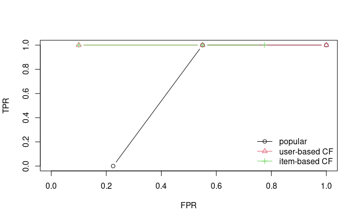

```r
# g) Plot the ROC curves for each of the methods and different values of N. What can you conclude?
plot(results, annotate="TRUE")
```

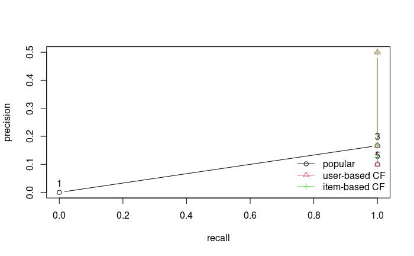

```r
# h) Plot the precision/recall curves for each of the methods and different values of N. What can you conclude?
plot(results, "prec/rec", annotate=TRUE)
```